# 3_FordGoBike_Exploratory_Part2 slides

## Exploratory Data Visualization Part 2

### Multivariate Exploration

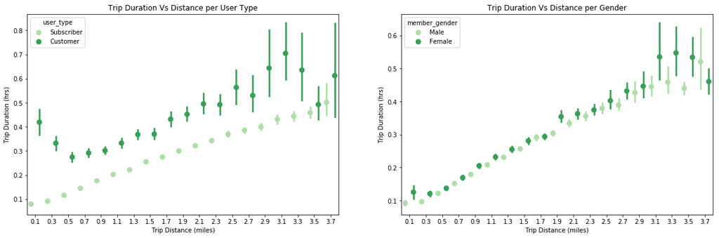

```python
fig, ax = plt.subplots(ncols = 2, figsize = [20,6])
age_group_order = ['10-20','20-30','30-40','40-50','50-60','60-70','70-100','100-140']

sb.pointplot(data=data, x = 'distance_mile_group', y = 'duration_hr', hue = 'user_type',
             palette = 'Greens', linestyles = '', dodge = 0.5, ax = ax[0])

ax[0].set_title('Trip Duration Vs Distance per User Type')
ax[0].set_ylabel('Trip Duration (hrs)')
ax[0].set_xlabel('Trip Distance (miles)')

sb.pointplot(data=data, x = 'distance_mile_group', y = 'duration_hr', hue = 'member_gender',
             palette = 'Greens', linestyles = '', dodge = 0.5, ax = ax[1])

ax[1].set_title('Trip Duration Vs Distance per Gender')
ax[1].set_ylabel('Trip Duration (hrs)')
ax[1].set_xlabel('Trip Distance (miles)')
plt.savefig(folder_plots + '\\'+'Multivariate_Distance_TripDuration_User_Gender.png')
plt.show();
```

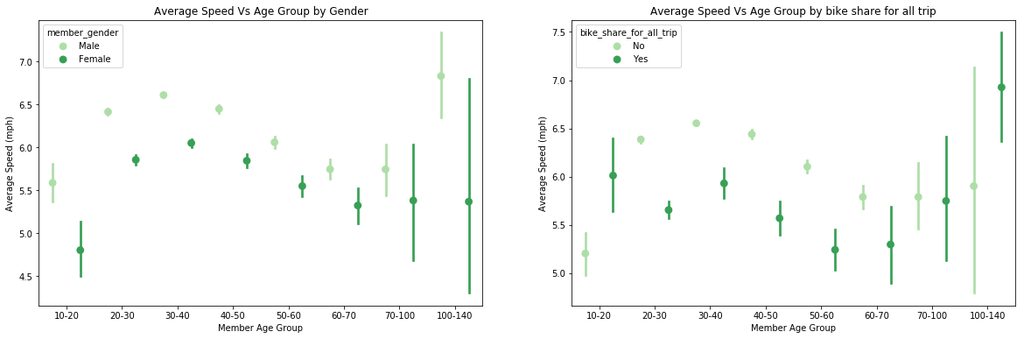

```python
fig, ax = plt.subplots(ncols = 2, figsize = [20,6])
age_group_order = ['10-20','20-30','30-40','40-50','50-60','60-70','70-100','100-140']

sb.pointplot(data=data, x = 'member_age_group', y = 'average_speed_mph', hue = 'member_gender',
             palette = 'Greens', linestyles = '', dodge = 0.5, ax = ax[0],order=age_group_order)
ax[0].set_title('Average Speed Vs Age Group by Gender')
ax[0].set_ylabel('Average Speed (mph)')
ax[0].set_xlabel('Member Age Group')

sb.pointplot(data=data, x = 'member_age_group', y = 'average_speed_mph', hue = 'bike_share_for_all_trip',
             palette = 'Greens', linestyles = '', dodge = 0.5, ax = ax[1],order=age_group_order)
ax[1].set_title('Average Speed Vs Age Group by bike share for all trip')
ax[1].set_ylabel('Average Speed (mph)')
ax[1].set_xlabel('Member Age Group')
plt.savefig(folder_plots + '\\'+'Multivariate_Speed_AgeGroup_Gender_share.png')
plt.show();
```

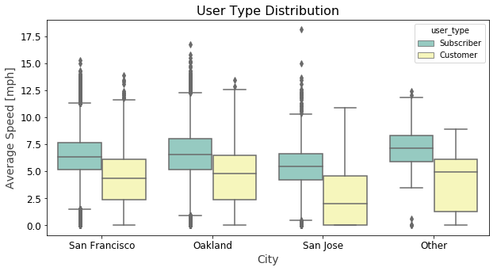

```python
folder_plots = 'plots'
plt.figure(figsize = [10, 5])
ax = sb.boxplot(x="city", y="average_speed_mph", hue="user_type",
                 data=df_plt, palette="Set3",order = ['San Francisco','Oakland','San Jose','Other'] )
ax.grid(False)
ax.tick_params(labelsize=12)
ax.set_xlabel("City",fontsize=14,alpha=0.75)
ax.set_ylabel("Average Speed [mph]",fontsize=14,alpha=0.75)
ax.axes.set_title("User Type Distribution",fontsize=16)
plt.savefig(folder_plots + '\\'+'Bivariate_AvgSpeed_User_Type_by_city.png');
```

> It seems that the subscriber average speed is consistently higher than customers in all city, which is expected as casual customers could be new to the area. Worth nothing that San Jose is the slowest for Customer but a bit higher for Subscriber. Need to investigate why this difference assuming the traffic congesion will be the same for all riders.

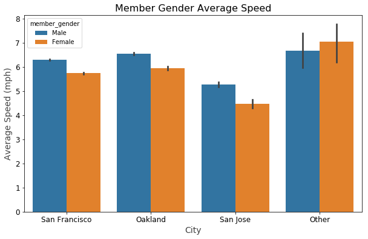

```python
plt.figure(figsize = [10, 6])

data = df_plt[df_plt.member_gender.isin(['Male', 'Female'])]

ax = sb.barplot(data = data, x = 'city',y = 'average_speed_mph', hue = 'member_gender')

ax.grid(False)
ax.tick_params(labelsize=12)
ax.set_xlabel("City",fontsize=14,alpha=0.75)
ax.set_ylabel("Average Speed (mph)",fontsize=14,alpha=0.75)
ax.axes.set_title("Member Gender Average Speed",fontsize=16)
plt.savefig(folder_plots + '\\'+'Bivariat_Gender_city_AvgSpeed.png');
```

Male average speed is generally higher than Female by at least 0.6mph for the three cities.

## Station Geo Data Analysis

### What are the Top Busiest Stations

> What we manuplating the dataset here are in relation to stations. We also create maps in order to show the representation of the usage of riders.

#### `Busy Hour (BH)` analysis by station

```python
#this will be used to show in the map but we may need to add city along with colomns for coordinates
df_station_hour = df_plt.groupby(['start_station_id','start_date','start_hour']).agg(
    {'start_hour':np.count_nonzero
    }).rename(columns={'start_hour':'hourly' }).reset_index()

df_station_date_BH  = df_station_hour.groupby(['start_station_id']).agg(
    {'hourly':np.max
    }).reset_index()

#Need to merge with df_station_hour so that start_date and start_hour for BH can be added.
df_station_date_BH = pd.merge(left=df_station_date_BH,right=df_station_hour, how='left',\
                  on=['start_station_id', 'hourly']).drop_duplicates(['start_station_id', 'hourly'])\
.rename(columns={'hourly':'max_rides_BH','start_date':'start_date_BH','start_hour':'start_hour_BH'})
#when found tie numbers only one is used
df_station_date_BH.nlargest(5,'max_rides_BH')
```

|  | start_station_id | max_rides_BH | start_date_BH | start_hour_BH |
| --- | --- | --- | --- | --- |
| 66 | 15 | 5 | 2018-12-19 | 8 |
| 67 | 16 | 5 | 2018-07-30 | 8 |
| 265 | 30 | 5 | 2018-09-20 | 9 |
| 527 | 67 | 5 | 2018-07-17 | 8 |
| 16 | 5 | 4 | 2019-02-21 | 9 |

#### `Busy Day (BD)` analysis by station

```python
#group by stations and start_date to find total rides per day for each station
df_station_date = df_plt.groupby(['start_station_id','start_date']).agg(
    {'start_date':np.count_nonzero
    }).rename(columns={'start_date':'date_ride_count' }).reset_index()

#find station maximum number of rides for the busiest day
df_station_BD = df_station_date.groupby(['start_station_id']).agg(
    {'date_ride_count':np.max}).reset_index()

df_station_BD = pd.merge(left=df_station_BD,right=df_station_date, how='left', \
                          on=['start_station_id', 'date_ride_count'])\
.drop_duplicates(['start_station_id', 'date_ride_count']) #when found tie numbers only one is used
df_station_BD = df_station_BD.rename(columns={'date_ride_count':'max_rides_BD','start_date':'start_date_BD'})
df_station_BD.nlargest(5,'max_rides_BD')
```

|  | start_station_id | max_rides_BD | start_date_BD |
| --- | --- | --- | --- |
| 35 | 21 | 13 | 2019-03-14 |
| 108 | 67 | 13 | 2018-08-14 |
| 26 | 15 | 11 | 2018-12-19 |
| 97 | 58 | 11 | 2019-03-07 |
| 27 | 16 | 10 | 2019-01-23 |

#### `Number of Days Station is in service and Total rides`

```python
#stations number of days in service
df_station_days  = df_station_date.groupby(['start_station_id']).agg(
    {'start_date':['nunique']
    }).rename(columns={'start_date':'station_ndays' }).reset_index()
df_station_days.columns = ["_".join(x) for x in df_station_days.columns.ravel()]
df_station_days  = df_station_days.rename(columns={'start_station_id_':'start_station_id','station_ndays_nunique':'station_ndays' })

#total number of rides per station
df_station_total  = df_station_date.groupby(['start_station_id']).agg(
    {'date_ride_count':np.sum
    }).rename(columns={'date_ride_count':'station_total' }).reset_index()

#merge number of days and total rides to determine the average number of rides per station
df_station_nDay = pd.merge(left=df_station_days,right=df_station_total, how='left',on=['start_station_id'])
#.drop_duplicates(['start_station_id', 'date_ride_count'])
df_station_nDay['avg_daily'] = df_station_nDay['station_total']/df_station_nDay['station_ndays']
df_station_nDay.nlargest(5,'station_total')
```

|  | start_station_id | station_ndays | station_total | avg_daily |
| --- | --- | --- | --- | --- |
| 12 | 15 | 560 | 1648 | 2.942857 |
| 60 | 67 | 479 | 1550 | 3.235908 |
| 52 | 58 | 539 | 1493 | 2.769944 |
| 27 | 30 | 474 | 1445 | 3.048523 |
| 72 | 81 | 499 | 1359 | 2.723447 |